# Лабораторная работа №10

Архитектура компьютеров

Мустафина А.Ю.

Российский университет дружбы народов, Москва, Россия

19 апреля 2025

## Цель работы

Познакомиться с операционной системой Linux. Получить практические навыки рабо- ты с редактором vi, установленным по умолчанию практически во всех дистрибутивах.

## Задание

1. Ознакомиться с теоретическим материалом.
2. Ознакомиться с редактором vi.
3. Выполнить упражнения, используя команды vi.

# Выполнение лабораторной работы

## Задание 1. Создание нового файла с использованием vi

Создала каталог с именем ~/work/os/lab06. Перешла во вновь созданный каталог. Вызвала vi и создала файл hello.sh и добавила нужный текст.

(рис. 1).

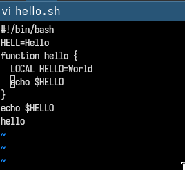

Новый каталог и текст

## Задание 1. Создание нового файла с использованием vi

Нажала клавишу Esc для перехода в командный режим после завершения ввода текста. Нажала : для перехода в режим последней строки и внизу экрана появится приглашение в виде двоеточия. Нажала w (записать) и q (выйти), а затем нажала клавишу Enter для сохранения текста и завершения работы. Сделала файл исполняемым `chmod +x hello.sh`

(рис. 2).

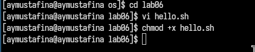

Переход в режим и исполняемый файл

## Задание 2. Редактирование существующего файла

Вызвала vi на редактирование файла `vi ~/work/os/lab06/hello.sh`

Установила курсор в конец слова HELL второй строки. Перешла в режим вставки и заменила на HELLO. Нажала Esc для возврата в команд- ный режим.(рис. 3).

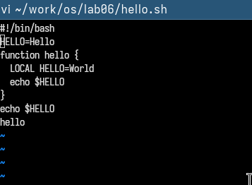

Замена HELL на HELLO

## Задание 2. Редактирование существующего файла

Установила курсор на четвертую строку и стерла слово LOCAL. Перейдите в режим вставки и наберите следующий текст: local, нажмите Esc для возврата в командный режим. Установите курсор на последней строке файла. Вставьте после неё строку, содержащую следующий текст: echo $HELLO.(рис. 4).

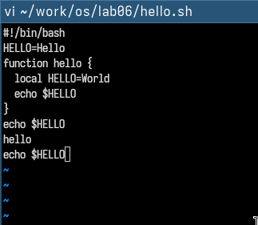

Добавление последней строки

## Задание 2. Редактирование существующего файла

Нажмите Esc для перехода в командный режим. Удалите последнюю строку.(рис. 5).

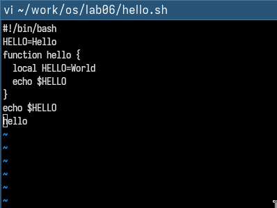

## Задание 2. Редактирование существующего файла

Введите команду отмены изменений u для отмены последней команды. Введите символ : для перехода в режим последней строки. Запишите произведённые изменения и выйдите из vi.(рис. 6).

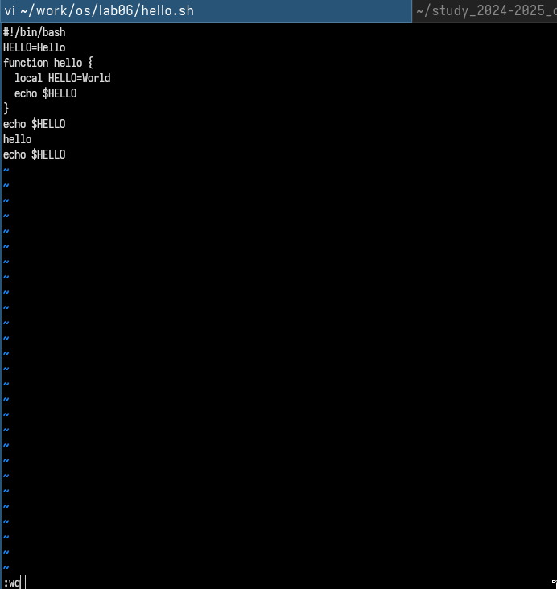

Выход

# Выводы

Познакомилсь с операционной системой Linux. Получила практические навыки рабо- ты с редактором vi, установленным по умолчанию практически во всех дистрибутивах.